# There is always a bigger data - a text mining analysis of the Star Wars original trilogy movie scripts

Dorottya Bencze

15.06.2018

From a textmining point of view movie scripts are very interesting. They are mainly consisting of dialogues, and since cinema is a medium that tells the whole story in the span of a couple of hours, emotions tend to run high as well. I analysed the Star Wars original trilogy movie scripts exploring the word usage in the trilogy as a whole as well as in the individual movies. I investigated the sentiment change throughout each movie, along with the most frequent words with positive and negative sentiments. I additionally explored the most common word choices of six main characters of the movies as well as the frequency they express the eight basic emotions found in the NRC emotion lexicon.

### The dataset

In this project I analysed the Star Wars original trilogy movie scripts downloaded from kaggle. The original text contained the humanly comprehensible dialogs from the three movies (so sadly the lines of both Chewbacca and R2D2 were left out). The text was arranged with each line having its own row, and the index of the current line together with the speaking character’s name was written at the beginning of each row. To prepare the text for analyis, I separated the line numbers and character names into distinct columns (“num”, “speaker” and “script” for the text). I combined the three movie scripts into one dataframe, and created a new variable (“movie”) as well.

```
## # A tibble: 5 x 4
##   num   speaker  script                                            movie
##   <chr> <chr>    <chr>                                             <chr>
## 1 1     THREEPIO Did you hear that?  They've shut down the main r~ A New ~
## 2 2     THREEPIO We're doomed!                                     A New ~
## 3 3     THREEPIO There'll be no escape for the Princess this time. A New ~
## 4 4     THREEPIO What's that?                                      A New ~
## 5 5     THREEPIO I should have known better than to trust the log~ A New ~
```

### Exploring the three movie scripts

To create a first impression of the verbal repertoire of the movies, I started by examining the trilogy together. First I created a word cloud of the most common words (excluding the stop words) in the movies, then explored the most prevalent relationships between words by separating the scripts into word pairs (bigrams) and calculating the pairs’ frequency.

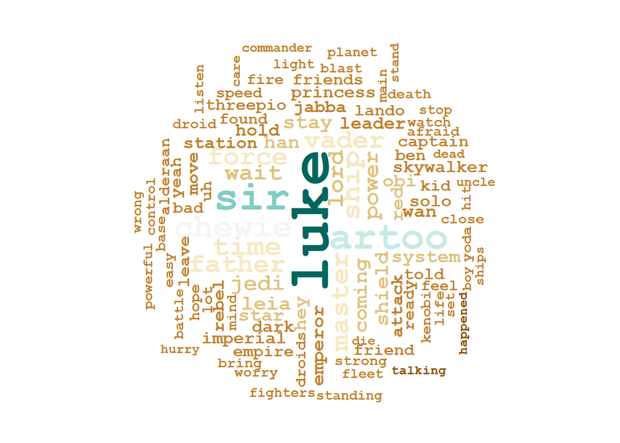

The combined word cloud of the movie trilogy shows that the most common word in the scripts is “Luke”, which is not suprising since the protagonist’s name is used fairly frequently in movies. Other regularly used words include “sir” and “artoo”, presumably by virtue of Threepio. Most of the main characters’ names are present in the wordcloud along with the franchise’s characteristic words like “jedi”, “ship” and “force”.

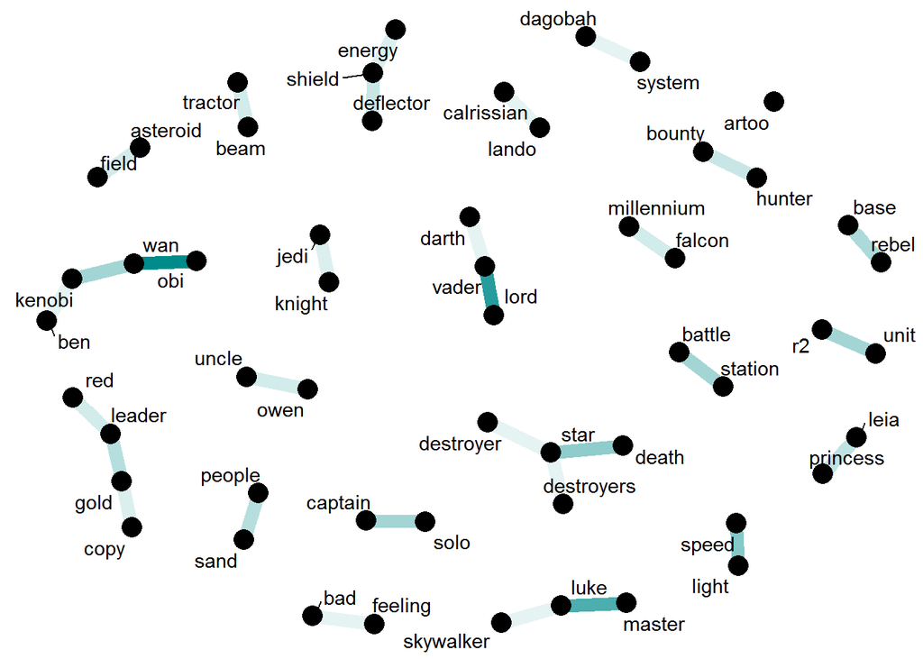

Looking at the graph illustrating the the word pairs frequantly present together, we can see that the movies only have a few clusters of expressions that are used together. Most of the frequent pairs are either names (obi-wan kenobi), titles (princess leia) or science fiction specific expressions (light speed, star destroyer). Among these most common bigrams the only pair that is not an established expression or name is “bad feeling”, which has become an iconic remark of the franchise.

[figure not shown]

### Comparing the three movies - sentiment analysis

After exploring the trilogy as a whole, we can take a look at the individual movies a bit more closely. First I checked how the sentiment changes throughout the course of each movie. After separating the scripts into words (excluding stop words), I conducted a sentiment analysis using the Bing library containing positive and negative sentiments. To examine the change of sentiment over time, i separated each movie into smaller segments (number of the movie’s lines devided by 10) and counted the emotional words in a segment. The overall sentiment of a segment was calculated by subtracting the number of negative words from the number of positive words.

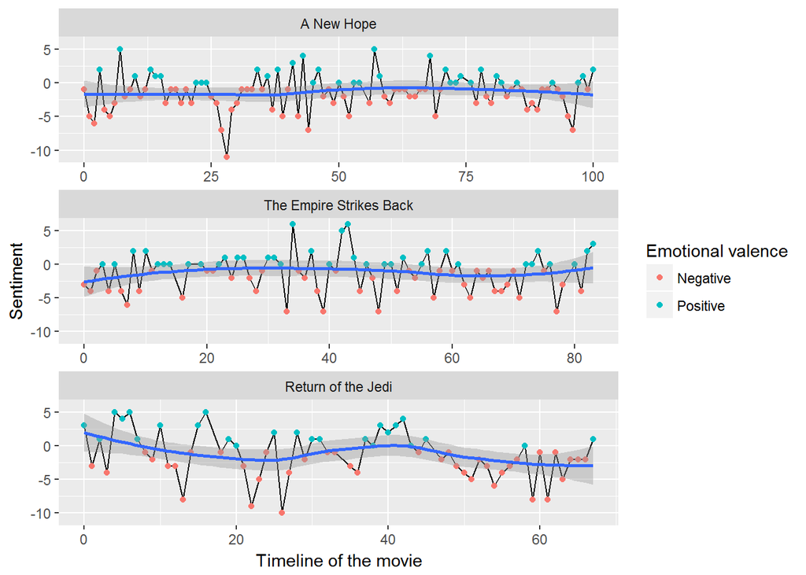

Comparing the changes in sentiment within the movies we see that the third movie of the trilogy, Return of the Jedi seem to be the most turbulent, due to its larger, more slowly changing peaks in sentiment. The other two movies have more rapid changes, both presenting higher peaks of alternating negative and positive sentiments at the beginning and in the middle of the movies. Despite the number of negative sentiments growing as we arrive to the last scenes of the movies, all three stories seem to end on a happy note.

To get a better picture of the sentiments in the three movies, next I examined the frequently used emotional words in each movie. I performed a sentiment analysis with the Bing library to get the 10 most common negative and positive words within each movie.

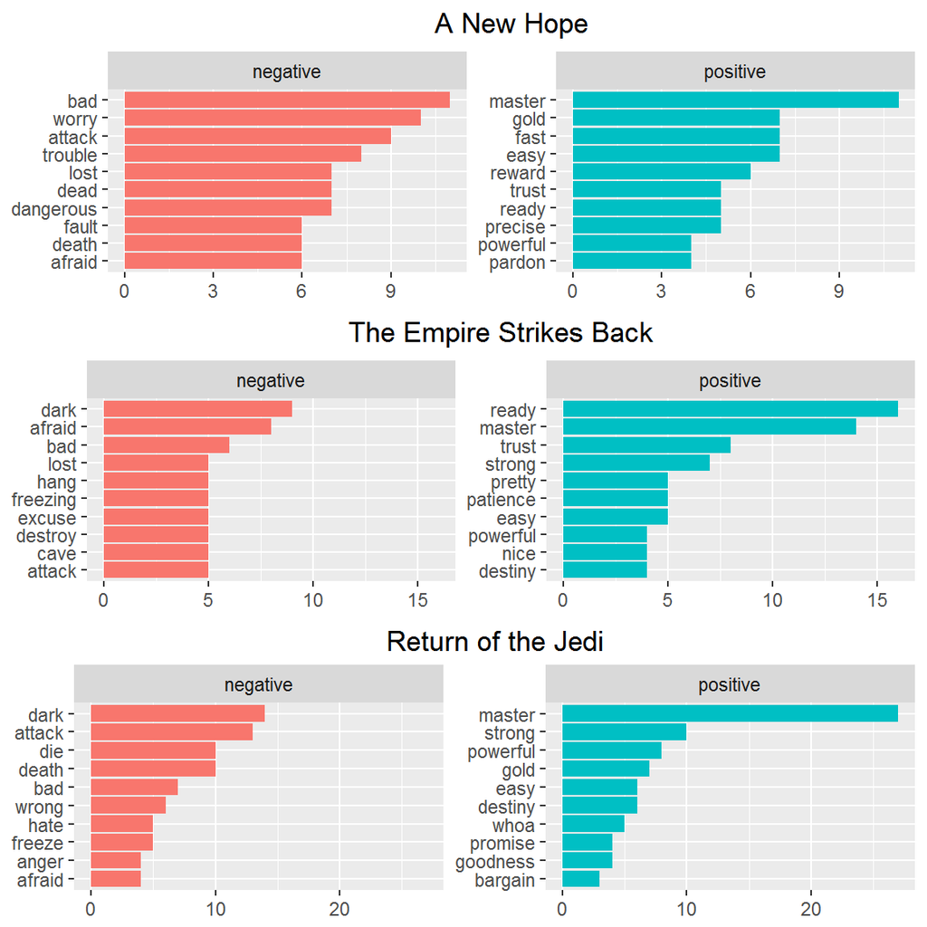

The most common negative word in the first movie in “bad”, which is replaced by “dark” in the second and third movies, presumably after we learn enough about the dark side of the Force for it to be a frequent topic. Both the second and the third movie seem to have a darker mood with the comparatively lighter negative words of the first movie (“bad”, “trouble”, “worry”) being replaced by more grim ones (“dark”, “attack”, “die”) on the top of the list. One of most frequent positive words in all moves is “master”, which is probably used as a noun in the movies, gives that Threepio often uses it as an honorific.

### Examining the characters

Since movie scripts mainly consist of dialogue, one of the most interesting things to investigate is the speaking characters’ word choices and sentiment. To narrow down which characters would be most interesting, I first checked which characters have an appropriately large number of lines (I picked 100 lines as a cutpoint) to provide enough data for the analysis.

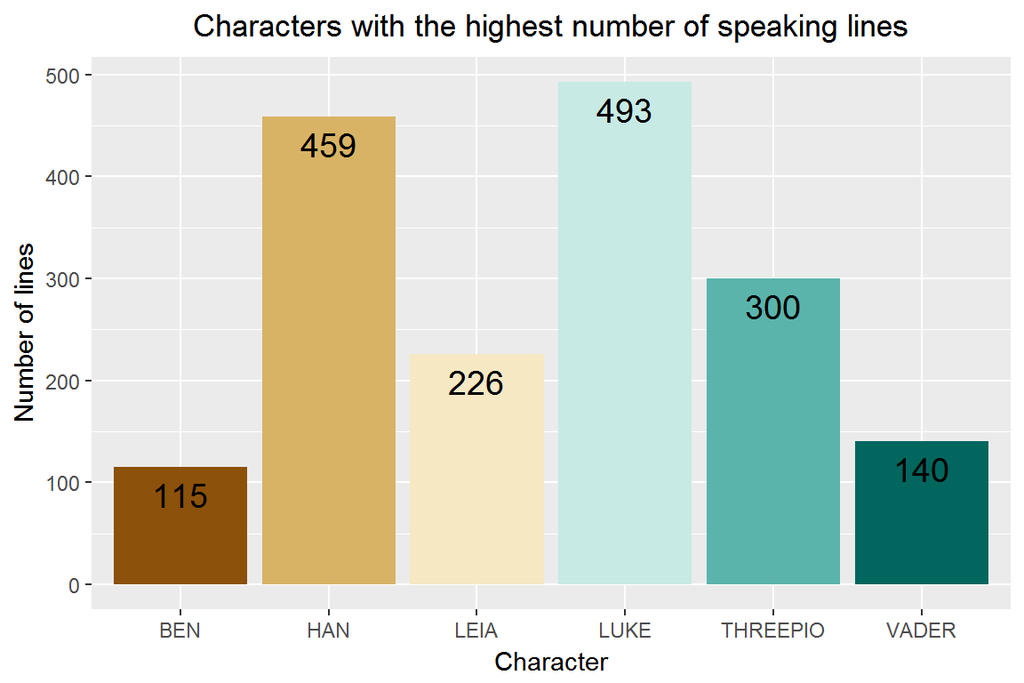

The characters with the most speaking lines are unsurprisingly the three protagonists (Han Solo, Luke and Leia) along with the main forces of good and evil in the trilogy (Ben Kenobi and Darth Vader). Threepio has surprisingly much lines for a side character, but it doesn’t come as a shock to anyone who has seen the movies.

In the two further analyses i focused on these 6 main characters. First I explored the most frequently used words (that are not stop words) for each character, comparing them with a comparison cloud.

[figure not shown]

In addition to the characters most commonly used words, it can be interesting to check what types of emotions they express most frequently. The NRC Emotion lexicon contains basic emotions (anger, trust, surprise, sadness, joy, fear, disgust, anticipation) and two sentiments (positive and negative). To compare the main characters emotional demeanor, I conducted a sentiment analysis for each character using the NRC lexicon, focusing on the eight emotions and leaving out the sentiments. Since there is a significant difference in the number of speaking lines between the characters, i calculated the ratio of the word count of each emotion and the total (not stop word) word count for each character for a better comparison.

[figure not shown]

The first glance at the radar chart tells us that the expression of the 8 examined emotions is pretty diverse between characters. We can make the general observation that disgust seems to be the most underrepresented emotion, while almost all of the characters express trust fairly regularly.

Han Solo seems to be the most emotive out of the main characters, he has the highest number of emotional words in almost all categories, particularly for positive emotions (anticipation, joy), but also for surprise. One of the surprising results is that fear doesn’t seem to be Threepio’s defining characteristic, instead Ben is the character who most regularly expresses fear. Despite the Dark Side supposedly stemming from one’s anger and fear, Darth Vader does not seem to express these emotions very often. He seems to be one of the least emotionally expressive characters, except for sadness (but this result might be simply an indicator of his disappointment in his underlings and their lack of faith).

[figure not shown]

### Summary

The text mining analysis of the Star Wars original trilogy movie scripts showed that for the trilogy as a whole, the most common words and word pairs are either names or science fiction / Star Wars specific expressions. Comparing the sentiments of the individual movies we saw that the third movie seems to be more turbulent than the other two, and the negative words used in the second and third movie were slightly more dark, than in the first movie. The analysis of the characters’ word choices showed that their most common words were almost always names as well as some characteristic words. The sentiment analysis focusing on 8 basic emotions showed that Han Solo seems to be the most emotive of the characters, and Darth Vader is one of the least emotionally expressive ones.

However, most of these methods are based on separating the words from their original context and determining their valence and emotional connotations on their own. Individual words often gain different meaning out of their context (eg. leaving out a “don’t” preceding a “worry”), so it is better to interpret these results with caution.